# OncoSimulR: forward genetic simulation in asexual populations with arbitrary epistatic interactions and a focus on modeling tumor progression.

## 10.4 Predator-prey, commensalism, and consumer-resource models

Since birth rates can be arbitrary functions of frequencies of other clones, we can easily model classical ecological models, such as predator-prey, competition, commensalism and, more generally, consumer-resource models (see, for example, section 3.4 in Otto and Day 2007).

OncoSimulR was originally designed as a forward-time genetic simulator; thus, we used to need to use a simple trick to get the system going. For example, suppose we want to model a predator-prey system; we could do this having a WT that can mutate into either preys or predators. (This is no longer necessary since we can specify starting the simulation from populations with arbitrary numbers of different clones; see sections 6.7 and 6.8. But we have not yet updated the examples).

We will use below the usual consumer-resource model with Lotka-Volterra equations. To model them, we use the “Exp” model, which has a constant death rate of 1, and directly translate the usual expressions (e.g., expressions 3.15a and 3.15b in p. 73 of Otto and Day 2007) for rates of change into the birth rate. Of course, you can use any other function for how rates of change of each “species” depend on the numbers of the different species, including constant inflow and outflow, Type I, Type II, and Type III functional responses, etc. And you can model systems that involve multiple different types of preys, predators, commensals, etc (see the example in 10.2 for a four-type example).

What about `sampleEvery`? In “for real” work, and specially with complex models, you might want to decrease it, or at least examine how much results are affected by changes in `sampleEvery`. Decreasing `sampleEvery` will result in birth rates being updated more frequently, and we use the BNB algorithm, which updates all rates only when the whole population is sampled. (Recall that by default, in the `McFL` and `McFLD` models the setting for `sampleEvery` is smaller than in the `Exp` model). Further discussion of these issues is provided in sections 10.7 and 15.6.

Since the WT genotype is just a trick used to get the system going, we will make sure it disappears from the system soon after we get it to have both preys and predators (and we use the max function to prevent birth rate from ever becoming negative or identically 0). Finally, note that we can make this much more sophisticated; for example, we could get the system going differently by having different mutations from WT to prey and predator. Remember that you can now start the simulation from arbitrary initial compositions (section 6.7). This is left here for historical purposes and to show additional use cases.

### 10.4.1 Competition

First, create a function that will generate the usual Lotka-Volterra expressions for competition models (see below for this example without using the WT, and directly starting from “S1” and “S2”).

```r
G_fe_LV <- function(r1, r2, K1, K2, a_12, a_21, awt = 1e-4,
                                 gt = c("WT", "S1", "S2")) {
    data.frame(Genotype = gt,
               Fitness = c(
                  paste0("max(0.1, 1 - ", awt, " * (n_2 + n_1))"),
                  paste0("1 + ", r1,
                         " * ( 1 - (n_1 + ", a_12, " * n_2)/", K1,
                         ")"),
                  paste0("1 + ", r2,
                         " * ( 1 - (n_2 + ", a_21, " * n_1)/", K2,
                         ")")
                  ))
}

## Show expressions for birth rates
G_fe_LV("r1", "r2", "K1", "K2", "a_12", "a_21", "awt")
##   Genotype                               Fitness
## 1       WT       max(0.1, 1 - awt * (n_2 + n_1))
## 2       S1 1 + r1 * ( 1 - (n_1 + a_12 * n_2)/K1)
## 3       S2 1 + r2 * ( 1 - (n_2 + a_21 * n_1)/K2)
```

Note we use numbers, not letters, in the expressions above (`n_1`, etc). This allows for reusing the function, but requires extra care making sure that the numbers match the order of the genotypes (it is not a problem with “S1” and “S2”, since there “S1” will always be 1 and “S2” 2; but what about “Predator” and “prey”?)

Now, run that model by setting appropriate parameters; see how we have $a\_12 > 0$ and $a\_21 > 0$.

```r
fe_competition <-
    allFitnessEffects(
        genotFitness =
            G_fe_LV(1.5, 1.4, 10000, 4000, 0.6, 0.2,
                  gt = c("WT","S1", "S2")),
        frequencyDependentFitness = TRUE,
        frequencyType = "abs")

competition <- oncoSimulIndiv(fe_competition,
                            model = "Exp",
                            onlyCancer = FALSE,
                            finalTime = 100,
                            mu = 1e-4,
                            initSize = 40000,
                            keepPhylog = TRUE,
                            seed = NULL,
                            errorHitMaxTries = FALSE,
                            errorHitWallTime = FALSE)
```

If we plot the whole simulation, we of course see the WT:

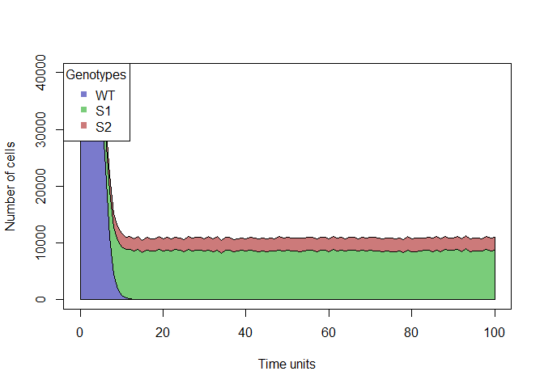

```r
plot(competition, show = "genotypes")
```

but we can avoid that by showing the plot after the WT are long gone:

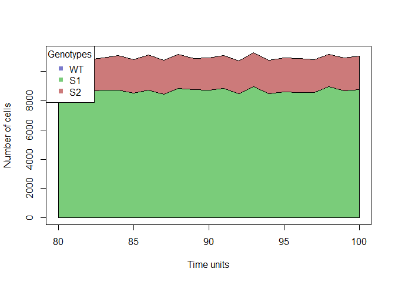

```r
plot(competition, show = "genotypes",
     xlim = c(80, 100))
```

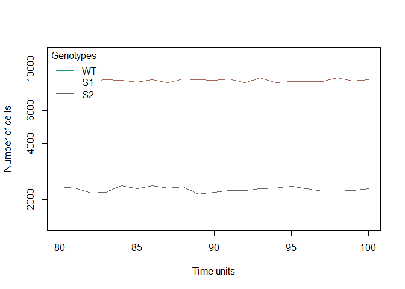

```r
plot(competition, show = "genotypes", type = "line",
     xlim = c(80, 100), ylim = c(1500, 12000))
```

### 10.4.2 Competition

We repeat the above, but starting directly from the two species, using the 6.8 logic and 6.7.

```r
G_fe_LVm <- function(r1, r2, K1, K2, a_12, a_21, awt = 1e-4,
                                 gt = c("S1", "S2")) {
    data.frame(Genotype = gt,
               Fitness = c(
                  paste0("1 + ", r1,
                         " * ( 1 - (n_1 + ", a_12, " * n_2)/", K1,
                         ")"),
                  paste0("1 + ", r2,
                         " * ( 1 - (n_2 + ", a_21, " * n_1)/", K2,
                         ")")
                  ))
}

## Show expressions for birth rates
G_fe_LVm("r1", "r2", "K1", "K2", "a_12", "a_21", "awt")
##   Genotype                               Fitness
## 1       S1 1 + r1 * ( 1 - (n_1 + a_12 * n_2)/K1)
## 2       S2 1 + r2 * ( 1 - (n_2 + a_21 * n_1)/K2)
```

```r
fe_competitionm <-
    allFitnessEffects(
        genotFitness =
            G_fe_LVm(1.5, 1.4, 10000, 4000, 0.6, 0.2,
                  gt = c("S1", "S2")),
        frequencyDependentFitness = TRUE)

fe_competitionm$full_FDF_spec
##   S1 S2 Genotype_as_numbers Genotype_as_letters Genotype_as_fvars
## 1  1  0                   1                  S1               n_1
## 2  0  1                   2                  S2               n_2
##                           Fitness_as_fvars
## 1 1 + 1.5 * ( 1 - (n_1 + 0.6 * n_2)/10000)
## 2  1 + 1.4 * ( 1 - (n_2 + 0.2 * n_1)/4000)
##                         Fitness_as_letters
## 1 1 + 1.5 * ( 1 - (n_1 + 0.6 * n_2)/10000)
## 2  1 + 1.4 * ( 1 - (n_2 + 0.2 * n_1)/4000)

competitionm <- oncoSimulIndiv(fe_competitionm,
                              model = "Exp",
                              initMutant = c("S1", "S2"),
                              initSize = c(5000, 2000),
                              onlyCancer = FALSE,
                              finalTime = 100,
                              mu = 1e-4,
                              keepPhylog = TRUE,
                              seed = NULL,
                              errorHitMaxTries = FALSE,
                              errorHitWallTime = FALSE)
```

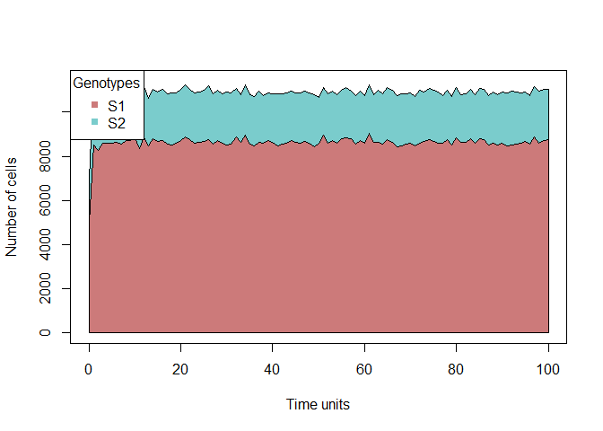

```r
plot(competitionm, show = "genotypes")
```

### 10.4.3 Predator-prey, first example

The simplest model would use the above Lotka-Volterra expressions and set one of the `a_` to be negative (see, for example, Otto and Day 2007, 73). Let’s turn former “S2” and thus `a_21 < 0` (to make the effects more salient, we also increase that value in magnitude).

We will also use a general function to generate fitness expressions. This is actually nicer than we did above, because it allows us to give the names of the species, not codes such as “n_1” that depend on how the names are ordered by R.

```r
G_fe_LVm2 <- function(r1, r2, K1, K2, a_12, a_21, awt = 1e-4,
                                 gt = c("S1", "S2")) {
    data.frame(Genotype = gt,
               Fitness = c(
                   paste0("1 + ", r1,
                         " * ( 1 - (n_", gt[1], " + ", a_12, " * n_", gt[2], ")/", K1,
                         ")"),
                  paste0("1 + ", r2,
                         " * ( 1 - (n_", gt[2], " + ", a_21, " * n_", gt[1], ")/", K2,
                         ")")
                  ))
}


## But notice that, because of ordering, "prey" ends up being n_2
## but that is not a problem.

fe_pred_preym2 <-
    allFitnessEffects(
        genotFitness =
            G_fe_LVm2(1.5, 1.4, 10000, 4000, 1.1, -0.5, awt = 1,
                  gt = c("prey", "Predator")),
        frequencyDependentFitness = TRUE)
## frequencyType set to 'auto'
## All single-gene genotypes as input to to_genotFitness_std
fe_pred_preym2$full_FDF_spec
##   Predator prey Genotype_as_numbers Genotype_as_letters
## 1        0    1                   2                prey
## 2        1    0                   1            Predator
##   Genotype_as_fvars                         Fitness_as_fvars
## 1               n_2 1 + 1.5 * ( 1 - (n_2 + 1.1 * n_1)/10000)
## 2               n_1 1 + 1.4 * ( 1 - (n_1 + -0.5 * n_2)/4000)
##                                   Fitness_as_letters
## 1 1 + 1.5 * ( 1 - (n_prey + 1.1 * n_Predator)/10000)
## 2 1 + 1.4 * ( 1 - (n_Predator + -0.5 * n_prey)/4000)

## Change order and note how these are, of course, equivalent

fe_pred_preym3 <-
    allFitnessEffects(
        genotFitness =
            G_fe_LVm2(1.4, 1.5, 4000, 10000, -0.5, 1.1, awt = 1,
                  gt = c("Predator", "prey")),
        frequencyDependentFitness = TRUE)
## frequencyType set to 'auto'
## All single-gene genotypes as input to to_genotFitness_std
fe_pred_preym3$full_FDF_spec
##   Predator prey Genotype_as_numbers Genotype_as_letters
## 1        1    0                   1            Predator
## 2        0    1                   2                prey
##   Genotype_as_fvars                         Fitness_as_fvars
## 1               n_1 1 + 1.4 * ( 1 - (n_1 + -0.5 * n_2)/4000)
## 2               n_2 1 + 1.5 * ( 1 - (n_2 + 1.1 * n_1)/10000)
##                                   Fitness_as_letters
## 1 1 + 1.4 * ( 1 - (n_Predator + -0.5 * n_prey)/4000)
## 2 1 + 1.5 * ( 1 - (n_prey + 1.1 * n_Predator)/10000)

evalAllGenotypes(fe_pred_preym2, spPopSizes = c(1000, 300))
## Warning in match_spPopSizes(spPopSizes, fmEffects): spPopSizes
## unnamed: cannot check genotype names.
##         Genotype Fitness
## 1             WT  0.0000
## 2       Predator  2.4700
## 3           prey  2.3005
## 4 Predator, prey  0.0000
evalAllGenotypes(fe_pred_preym3, spPopSizes = c(300, 1000))
## Warning in match_spPopSizes(spPopSizes, fmEffects): spPopSizes
## unnamed: cannot check genotype names.
##         Genotype Fitness
## 1             WT  0.0000
## 2       Predator  2.4700
## 3           prey  2.3005
## 4 Predator, prey  0.0000
```

```r
s_pred_preym2 <- oncoSimulIndiv(fe_pred_preym2,
                                model = "Exp",
                                initMutant = c("prey", "Predator"),
                                initSize = c(1000, 1000),
                                onlyCancer = FALSE,
                                finalTime = 200,
                                mu = 1e-3,
                                keepPhylog = TRUE,
                                seed = NULL,
                                errorHitMaxTries = FALSE,
                                errorHitWallTime = FALSE)
```

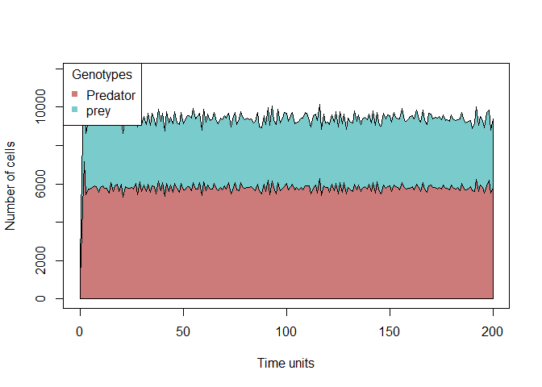

```r
plot(s_pred_preym2, show = "genotypes")
```

You can easily play with a range of parameters, say the carrying capacity of one of the species, to see how they affect the stochasticity of the system.

If you run the above model repeatedly, you will frequently find that only one of the species is left; and, yes, that could be the “Predator”, as in the Lotka-Volterra expressions above there can be predators without prey. For example, you can check that the birth rate of the predator is larger than 1 even if there are 0 prey (identically 1 when `n_1` = `K_1`:

```r
evalAllGenotypes(fe_pred_preym2, spPopSizes = c(0, 300))
## Warning in match_spPopSizes(spPopSizes, fmEffects): spPopSizes
## unnamed: cannot check genotype names.
##         Genotype Fitness
## 1             WT  0.0000
## 2       Predator  2.2950
## 3           prey  2.4505
## 4 Predator, prey  0.0000

evalAllGenotypes(allFitnessEffects(
    genotFitness =
        G_fe_LVm2(1.5, 1.4, 100, 40,
                  0.6, -0.5, awt = 0.1,
                  gt = c("prey", "Predator")),
    frequencyDependentFitness = TRUE),
    spPopSizes = c(0, 40))
## frequencyType set to 'auto'
## All single-gene genotypes as input to to_genotFitness_std
## Warning in match_spPopSizes(spPopSizes, fmEffects): spPopSizes
## unnamed: cannot check genotype names.
##         Genotype Fitness
## 1             WT    0.00
## 2       Predator    1.00
## 3           prey    2.14
## 4 Predator, prey    0.00
```

### 10.4.4 Predator-prey, second example

We use now the model in p. 76 of Otto and Day (2007), where prey grow exponentially in the absence of predators (and predators will eventually go extinct in the absence of prey):

$$\frac{\mathrm{d}n_1}{\mathrm{d}t} = r\ n_1 - a\ c\ n_1\ n_2$$
$$\frac{\mathrm{d}n_2}{\mathrm{d}t} = \epsilon\ a\ c\ n_1\ n_2 - \delta\ n2$$

```r
C_fe_pred_prey2 <- function(r, a, c, e, d,
                           gt = c("s1", "s2")) {
    data.frame(Genotype = gt,
               Fitness = c(
                   paste0("1 + ", r, " - ", a,
                          " * ", c, " * n_2"),
                   paste0("1 + ", e, " * ", a,
                          " * ", c, " * n_1 - ", d)
               ))
}

C_fe_pred_prey2("r", "a", "c", "e", "d")
##   Genotype                 Fitness
## 1       s1     1 + r - a * c * n_2
## 2       s2 1 + e * a * c * n_1 - d
```

Given how we wrote `C_fe_pred_prey2`, the prey is hardcoded as `n_1`, so specify names of creatures so that the prey comes first, in terms of order (note we avoided this problem in the example above, 10.4.3, by always using the full name of the genotype we refered to in the function to generate the fitness effects, `G_fe_LVm2`). (Yes, we could have used a classic pair: “Hare” and “Lynx”).

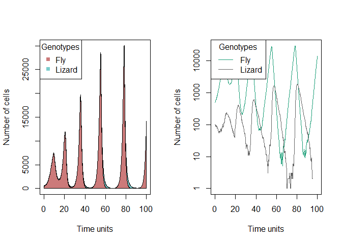

```r
fe_pred_prey2 <-
    allFitnessEffects(
        genotFitness =
            C_fe_pred_prey2(r = .7, a = 1, c = 0.005,
                            e = 0.02, d = 0.4,
                            gt = c("Fly", "Lizard")),
        frequencyDependentFitness = TRUE)
## frequencyType set to 'auto'
## All single-gene genotypes as input to to_genotFitness_std


fe_pred_prey2$full_FDF_spec
##   Fly Lizard Genotype_as_numbers Genotype_as_letters
## 1   1      0                   1                 Fly
## 2   0      1                   2              Lizard
##   Genotype_as_fvars                 Fitness_as_fvars
## 1               n_1        1 + 0.7 - 1 * 0.005 * n_2
## 2               n_2 1 + 0.02 * 1 * 0.005 * n_1 - 0.4
##                 Fitness_as_letters
## 1        1 + 0.7 - 1 * 0.005 * n_2
## 2 1 + 0.02 * 1 * 0.005 * n_1 - 0.4

## You want to make sure you start the simulation from
## a viable condition

evalAllGenotypes(fe_pred_prey2,
                 spPopSizes = c(5000, 100))
## Warning in match_spPopSizes(spPopSizes, fmEffects): spPopSizes
## unnamed: cannot check genotype names.
##      Genotype Fitness
## 1          WT     0.0
## 2         Fly     1.2
## 3      Lizard     1.1
## 4 Fly, Lizard     0.0

set.seed(2)
pred_prey2 <- oncoSimulIndiv(fe_pred_prey2,
                             model = "Exp",
                             initMutant = c("Fly", "Lizard"),
                             initSize = c(500, 100),
                             sampleEvery = 0.1,
                             mu = 1e-3,
                             onlyCancer = FALSE,
                             finalTime = 100,
                             keepPhylog = TRUE,
                             seed = NULL,
                             errorHitMaxTries = FALSE,
                             errorHitWallTime = FALSE)
op <- par(mfrow = c(1, 2))
## Nicer colors
plot(pred_prey2, show = "genotypes")
## But this shows better what is going on
plot(pred_prey2, show = "genotypes", type = "line")
```

```r
par(op)
```

If you run that model repeatedly, sometimes the system will go extinct quickly, or you will only get prey growing exponentially.

You could now (left as an exercise) build a more complex model to simulate arms-race scenarios between predators and prey (maybe by having mutations with possibly opposing effects on different coefficients above).

### 10.4.5 Commensalism

Modelling commensalism simply requires changing the values of the $\alpha$, the `a_12` and `a_21`. Again, we can now avoid starting from a WT and start the simulation directly from “A” and “Commensal” (section 6.7).

For example (not run, as this is just repetitive):

```r
fe_commens <-
    allFitnessEffects(
        genotFitness =
            G_fe_LV(1.2, 1.3, 5000, 20000,
                                 0, -0.2,
                                 gt = c("WT","A", "Commensal")),
        frequencyDependentFitness = TRUE,
        frequencyType = "abs")

commens <- oncoSimulIndiv(fe_commens,
                            model = "Exp",
                            onlyCancer = FALSE,
                            finalTime = 100,
                            mu = 1e-4,
                            initSize = 40000,
                            keepPhylog = TRUE,
                            seed = NULL,
                            errorHitMaxTries = FALSE,
                            errorHitWallTime = FALSE)

plot(commens, show = "genotypes")

plot(commens, show = "genotypes",
     xlim = c(80, 100))

plot(commens, show = "genotypes", type = "line",
     xlim = c(80, 100), ylim = c(2000, 22000))
```

## 10.5 Frequency-dependent fitness: can I mix relative and absolute frequencies?

Yes, of course, since you can always use an absolute specification with the appropriate quotient. For example, the following two specifications are identical:

```r
rar <- data.frame(Genotype = c("WT", "A", "B", "C"),
                 Fitness = c("1",
                             "1.1 + .3*f_2",
                             "1.2 + .4*f_1",
                             "1.0 + .5 * (f_1 + f_2)"))
afear <- allFitnessEffects(genotFitness = rar,
                         frequencyDependentFitness = TRUE,
                         frequencyType = "rel")

evalAllGenotypes(afear, spPopSizes = c(100, 200, 300, 400))
## Warning in match_spPopSizes(spPopSizes, fmEffects): spPopSizes
## unnamed: cannot check genotype names.
##   Genotype Fitness
## 1       WT    1.00
## 2        A    1.19
## 3        B    1.28
## 4        C    1.25
## 5     A, B    0.00
## 6     A, C    0.00
## 7     B, C    0.00
## 8  A, B, C    0.00


rar2 <- data.frame(Genotype = c("WT", "A", "B", "C"),
                 Fitness = c("1",
                             "1.1 + .3*(n_2/N)",
                             "1.2 + .4*(n_1/N)",
                             "1.0 + .5 * ((n_1 + n_2)/N)"))
afear2 <- allFitnessEffects(genotFitness = rar2,
                         frequencyDependentFitness = TRUE,
                         frequencyType = "abs")

evalAllGenotypes(afear2, spPopSizes = c(100, 200, 300, 400))
## Warning in match_spPopSizes(spPopSizes, fmEffects): spPopSizes
## unnamed: cannot check genotype names.
##   Genotype Fitness
## 1       WT    1.00
## 2        A    1.19
## 3        B    1.28
## 4        C    1.25
## 5     A, B    0.00
## 6     A, C    0.00
## 7     B, C    0.00
## 8  A, B, C    0.00
```

and simulating with them leads to identical results

```r
set.seed(1)
tmp1 <- oncoSimulIndiv(afear,
                       model = "McFL",
                       onlyCancer = FALSE,
                       finalTime = 30,
                       mu = 1e-4,
                       initSize = 5000,
                       keepPhylog = FALSE,
                       seed = NULL,
                       errorHitMaxTries = FALSE,
                       errorHitWallTime = FALSE)

set.seed(1)
tmp2 <- oncoSimulIndiv(afear2,
                       model = "McFL",
                       onlyCancer = FALSE,
                       finalTime = 30,
                       mu = 1e-4,
                       initSize = 5000,
                       keepPhylog = FALSE,
                       seed = NULL,
                       errorHitMaxTries = FALSE,
                       errorHitWallTime = FALSE)
stopifnot(identical(print(tmp1), print(tmp2)))
##
## Individual OncoSimul trajectory with call:
##  oncoSimulIndiv(fp = afear, model = "McFL", mu = 1e-04, initSize = 5000,
##     finalTime = 30, onlyCancer = FALSE, keepPhylog = FALSE, errorHitWallTime = FALSE,
##     errorHitMaxTries = FALSE, seed = NULL)
##
##   NumClones TotalPopSize LargestClone MaxNumDrivers MaxDriversLast
## 1         4         5072         4748             0              0
##   NumDriversLargestPop TotalPresentDrivers FinalTime NumIter
## 1                    0                   0        30    1250
##   HittedWallTime HittedMaxTries     errorMF minDMratio minBMratio
## 1          FALSE          FALSE 0.006620645   3219.745   3333.333
##   OccurringDrivers
## 1
##
## Final population composition:
##   Genotype    N
## 1          4748
## 2        A   46
## 3        B  273
## 4        C    5
##
## Individual OncoSimul trajectory with call:
##  oncoSimulIndiv(fp = afear2, model = "McFL", mu = 1e-04, initSize = 5000,
##     finalTime = 30, onlyCancer = FALSE, keepPhylog = FALSE, errorHitWallTime = FALSE,
##     errorHitMaxTries = FALSE, seed = NULL)
##
##   NumClones TotalPopSize LargestClone MaxNumDrivers MaxDriversLast
## 1         4         5072         4748             0              0
##   NumDriversLargestPop TotalPresentDrivers FinalTime NumIter
## 1                    0                   0        30    1250
##   HittedWallTime HittedMaxTries     errorMF minDMratio minBMratio
## 1          FALSE          FALSE 0.006620645   3219.745   3333.333
##   OccurringDrivers
## 1
##
## Final population composition:
##   Genotype    N
## 1          4748
## 2        A   46
## 3        B  273
## 4        C    5
```

So you can always mix relative and absolute; here fitness of two genotypes depends on the relative frequencies of others, whereas fitness of the third on the absolute frequencies (number of cells):

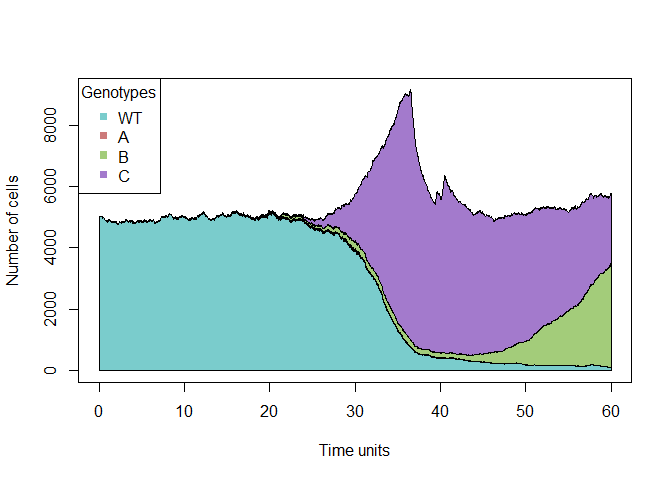

```r
rar3 <- data.frame(Genotype = c("WT", "A", "B", "C"),
                 Fitness = c("1",
                             "1.1 + .3*(n_2/N)",
                             "1.2 + .4*(n_1/N)",
                             "1.0 + .5 * ( n_1 > 20)"))
afear3 <- allFitnessEffects(genotFitness = rar3,
                         frequencyDependentFitness = TRUE,
                         frequencyType = "abs")

evalAllGenotypes(afear3, spPopSizes = c(100, 200, 300, 400))
## Warning in match_spPopSizes(spPopSizes, fmEffects): spPopSizes
## unnamed: cannot check genotype names.
##   Genotype Fitness
## 1       WT    1.00
## 2        A    1.19
## 3        B    1.28
## 4        C    1.50
## 5     A, B    0.00
## 6     A, C    0.00
## 7     B, C    0.00
## 8  A, B, C    0.00


set.seed(1)
tmp3 <- oncoSimulIndiv(afear3,
                       model = "McFL",
                       onlyCancer = FALSE,
                       finalTime = 60,
                       mu = 1e-4,
                       initSize = 5000,
                       keepPhylog = FALSE,
                       seed = NULL,
                       errorHitMaxTries = FALSE,
                       errorHitWallTime = FALSE)
plot(tmp3, show = "genotypes")
```